# Risk Factor Analysis

## Outcome Variable

**Outcome Variable:** wasted

## Predictor Variables

**Intervention Variable:** exclfeed36

**Adjustment Set:**

- arm
- sex
- brthmon
- W_mage
- meducyrs
- feducyrs
- hhwealth_quart
- hfoodsec
- W_mhtcm
- W_mwtkg
- W_mbmi
- vagbrth
- W_gagebrth
- W_birthwt
- W_birthlen
- W_nrooms
- W_nchldlt5
- month
- W_parity
- impfloor
- impsan
- safeh20
- delta_W_mage
- delta_meducyrs
- delta_feducyrs
- delta_hhwealth_quart
- delta_hfoodsec
- delta_W_mhtcm
- delta_W_mwtkg
- delta_W_mbmi
- delta_vagbrth
- delta_W_gagebrth
- delta_W_birthwt
- delta_W_birthlen
- delta_W_nrooms
- delta_W_nchldlt5
- delta_month
- delta_W_parity
- delta_impfloor
- delta_impsan
- delta_safeh20

## Stratifying Variables

The analysis was stratified on these variable(s):

- agecat
- studyid
- country

## Data Summary

| agecat | studyid | country | exclfeed36 | wasted | n_cell | n |
| --- | --- | --- | --- | --- | --- | --- |
| Birth | ki0047075b-MAL-ED | BANGLADESH | 1 | 0 | 27 | 208 |
| Birth | ki0047075b-MAL-ED | BANGLADESH | 1 | 1 | 4 | 208 |
| Birth | ki0047075b-MAL-ED | BANGLADESH | 0 | 0 | 147 | 208 |
| Birth | ki0047075b-MAL-ED | BANGLADESH | 0 | 1 | 30 | 208 |
| Birth | ki0047075b-MAL-ED | BRAZIL | 1 | 0 | 4 | 62 |
| Birth | ki0047075b-MAL-ED | BRAZIL | 1 | 1 | 0 | 62 |
| Birth | ki0047075b-MAL-ED | BRAZIL | 0 | 0 | 56 | 62 |
| Birth | ki0047075b-MAL-ED | BRAZIL | 0 | 1 | 2 | 62 |
| Birth | ki0047075b-MAL-ED | INDIA | 1 | 0 | 1 | 40 |
| Birth | ki0047075b-MAL-ED | INDIA | 1 | 1 | 0 | 40 |
| Birth | ki0047075b-MAL-ED | INDIA | 0 | 0 | 34 | 40 |
| Birth | ki0047075b-MAL-ED | INDIA | 0 | 1 | 5 | 40 |
| Birth | ki0047075b-MAL-ED | NEPAL | 1 | 0 | 0 | 25 |
| Birth | ki0047075b-MAL-ED | NEPAL | 1 | 1 | 0 | 25 |
| Birth | ki0047075b-MAL-ED | NEPAL | 0 | 0 | 23 | 25 |
| Birth | ki0047075b-MAL-ED | NEPAL | 0 | 1 | 2 | 25 |
| Birth | ki0047075b-MAL-ED | PERU | 1 | 0 | 5 | 218 |
| Birth | ki0047075b-MAL-ED | PERU | 1 | 1 | 0 | 218 |
| Birth | ki0047075b-MAL-ED | PERU | 0 | 0 | 208 | 218 |
| Birth | ki0047075b-MAL-ED | PERU | 0 | 1 | 5 | 218 |
| Birth | ki0047075b-MAL-ED | SOUTH AFRICA | 1 | 0 | 1 | 104 |
| Birth | ki0047075b-MAL-ED | SOUTH AFRICA | 1 | 1 | 0 | 104 |
| Birth | ki0047075b-MAL-ED | SOUTH AFRICA | 0 | 0 | 94 | 104 |
| Birth | ki0047075b-MAL-ED | SOUTH AFRICA | 0 | 1 | 9 | 104 |
| Birth | ki0047075b-MAL-ED | TANZANIA, UNITED REPUBLIC OF | 1 | 0 | 0 | 111 |
| Birth | ki0047075b-MAL-ED | TANZANIA, UNITED REPUBLIC OF | 1 | 1 | 0 | 111 |
| Birth | ki0047075b-MAL-ED | TANZANIA, UNITED REPUBLIC OF | 0 | 0 | 110 | 111 |
| Birth | ki0047075b-MAL-ED | TANZANIA, UNITED REPUBLIC OF | 0 | 1 | 1 | 111 |
| Birth | ki1000108-CMC-V-BCS-2002 | INDIA | 1 | 0 | 3 | 3 |
| Birth | ki1000108-CMC-V-BCS-2002 | INDIA | 1 | 1 | 0 | 3 |

[output cut: 162 more lines]

The following strata were considered:

- agecat: 24 months, studyid: ki0047075b-MAL-ED, country: BANGLADESH
- agecat: 24 months, studyid: ki0047075b-MAL-ED, country: BRAZIL
- agecat: 24 months, studyid: ki0047075b-MAL-ED, country: INDIA
- agecat: 24 months, studyid: ki0047075b-MAL-ED, country: NEPAL
- agecat: 24 months, studyid: ki0047075b-MAL-ED, country: PERU
- agecat: 24 months, studyid: ki0047075b-MAL-ED, country: SOUTH AFRICA
- agecat: 24 months, studyid: ki0047075b-MAL-ED, country: TANZANIA, UNITED REPUBLIC OF
- agecat: 24 months, studyid: ki1000108-CMC-V-BCS-2002, country: INDIA
- agecat: 24 months, studyid: ki1000108-IRC, country: INDIA
- agecat: 24 months, studyid: ki1000109-EE, country: PAKISTAN
- agecat: 24 months, studyid: ki1017093b-PROVIDE, country: BANGLADESH
- agecat: 24 months, studyid: ki1101329-Keneba, country: GAMBIA
- agecat: 24 months, studyid: ki1113344-GMS-Nepal, country: NEPAL
- agecat: 24 months, studyid: ki1148112-LCNI-5, country: MALAWI
- agecat: 24 months, studyid: kiGH5241-JiVitA-3, country: BANGLADESH
- agecat: 24 months, studyid: kiGH5241-JiVitA-4, country: BANGLADESH
- agecat: 6 months, studyid: ki0047075b-MAL-ED, country: BANGLADESH
- agecat: 6 months, studyid: ki0047075b-MAL-ED, country: BRAZIL
- agecat: 6 months, studyid: ki0047075b-MAL-ED, country: INDIA
- agecat: 6 months, studyid: ki0047075b-MAL-ED, country: NEPAL
- agecat: 6 months, studyid: ki0047075b-MAL-ED, country: PERU
- agecat: 6 months, studyid: ki0047075b-MAL-ED, country: SOUTH AFRICA
- agecat: 6 months, studyid: ki0047075b-MAL-ED, country: TANZANIA, UNITED REPUBLIC OF
- agecat: 6 months, studyid: ki1000108-CMC-V-BCS-2002, country: INDIA
- agecat: 6 months, studyid: ki1000108-IRC, country: INDIA
- agecat: 6 months, studyid: ki1000109-EE, country: PAKISTAN
- agecat: 6 months, studyid: ki1000304b-SAS-FoodSuppl, country: INDIA
- agecat: 6 months, studyid: ki1017093b-PROVIDE, country: BANGLADESH
- agecat: 6 months, studyid: ki1101329-Keneba, country: GAMBIA
- agecat: 6 months, studyid: ki1113344-GMS-Nepal, country: NEPAL
- agecat: 6 months, studyid: ki1148112-LCNI-5, country: MALAWI
- agecat: 6 months, studyid: kiGH5241-JiVitA-3, country: BANGLADESH
- agecat: 6 months, studyid: kiGH5241-JiVitA-4, country: BANGLADESH
- agecat: Birth, studyid: ki0047075b-MAL-ED, country: BANGLADESH
- agecat: Birth, studyid: ki0047075b-MAL-ED, country: BRAZIL
- agecat: Birth, studyid: ki0047075b-MAL-ED, country: INDIA
- agecat: Birth, studyid: ki0047075b-MAL-ED, country: NEPAL
- agecat: Birth, studyid: ki0047075b-MAL-ED, country: PERU
- agecat: Birth, studyid: ki0047075b-MAL-ED, country: SOUTH AFRICA
- agecat: Birth, studyid: ki0047075b-MAL-ED, country: TANZANIA, UNITED REPUBLIC OF
- agecat: Birth, studyid: ki1000108-CMC-V-BCS-2002, country: INDIA
- agecat: Birth, studyid: ki1000108-IRC, country: INDIA
- agecat: Birth, studyid: ki1000109-EE, country: PAKISTAN
- agecat: Birth, studyid: ki1017093b-PROVIDE, country: BANGLADESH
- agecat: Birth, studyid: ki1101329-Keneba, country: GAMBIA
- agecat: Birth, studyid: ki1113344-GMS-Nepal, country: NEPAL
- agecat: Birth, studyid: kiGH5241-JiVitA-3, country: BANGLADESH
- agecat: Birth, studyid: kiGH5241-JiVitA-4, country: BANGLADESH

### Dropped Strata

Some strata were dropped due to rare outcomes:

- agecat: Birth, studyid: ki0047075b-MAL-ED, country: BANGLADESH
- agecat: Birth, studyid: ki0047075b-MAL-ED, country: BRAZIL
- agecat: Birth, studyid: ki0047075b-MAL-ED, country: INDIA
- agecat: Birth, studyid: ki0047075b-MAL-ED, country: NEPAL
- agecat: Birth, studyid: ki0047075b-MAL-ED, country: PERU
- agecat: Birth, studyid: ki0047075b-MAL-ED, country: SOUTH AFRICA
- agecat: Birth, studyid: ki0047075b-MAL-ED, country: TANZANIA, UNITED REPUBLIC OF
- agecat: Birth, studyid: ki1000108-CMC-V-BCS-2002, country: INDIA
- agecat: Birth, studyid: ki1000108-IRC, country: INDIA
- agecat: Birth, studyid: ki1000109-EE, country: PAKISTAN
- agecat: 6 months, studyid: ki0047075b-MAL-ED, country: BANGLADESH
- agecat: 6 months, studyid: ki0047075b-MAL-ED, country: BRAZIL
- agecat: 6 months, studyid: ki0047075b-MAL-ED, country: INDIA
- agecat: 6 months, studyid: ki0047075b-MAL-ED, country: NEPAL
- agecat: 6 months, studyid: ki0047075b-MAL-ED, country: PERU
- agecat: 6 months, studyid: ki0047075b-MAL-ED, country: SOUTH AFRICA
- agecat: 6 months, studyid: ki0047075b-MAL-ED, country: TANZANIA, UNITED REPUBLIC OF
- agecat: 6 months, studyid: ki1000108-CMC-V-BCS-2002, country: INDIA
- agecat: 6 months, studyid: ki1000108-IRC, country: INDIA
- agecat: 6 months, studyid: ki1000109-EE, country: PAKISTAN
- agecat: 6 months, studyid: ki1000304b-SAS-FoodSuppl, country: INDIA
- agecat: 6 months, studyid: ki1017093b-PROVIDE, country: BANGLADESH
- agecat: 6 months, studyid: ki1148112-LCNI-5, country: MALAWI
- agecat: 24 months, studyid: ki0047075b-MAL-ED, country: BANGLADESH
- agecat: 24 months, studyid: ki0047075b-MAL-ED, country: BRAZIL
- agecat: 24 months, studyid: ki0047075b-MAL-ED, country: INDIA
- agecat: 24 months, studyid: ki0047075b-MAL-ED, country: NEPAL
- agecat: 24 months, studyid: ki0047075b-MAL-ED, country: PERU
- agecat: 24 months, studyid: ki0047075b-MAL-ED, country: SOUTH AFRICA
- agecat: 24 months, studyid: ki0047075b-MAL-ED, country: TANZANIA, UNITED REPUBLIC OF
- agecat: 24 months, studyid: ki1000108-CMC-V-BCS-2002, country: INDIA
- agecat: 24 months, studyid: ki1000108-IRC, country: INDIA
- agecat: 24 months, studyid: ki1000109-EE, country: PAKISTAN
- agecat: 24 months, studyid: ki1148112-LCNI-5, country: MALAWI

## Methods Detail

We’re interested in the causal parameters $E[Y_a]$ for all values of $a \in \mathcal{A}$. These parameters represent the mean outcome if, possibly contrary to fact, we intervened to set all units to have $A=a$. Under the randomization and positivity assumptions, these are identified by the statistical parameters $\psi_a=E_W[E_{Y|A,W}(Y|A=a,W)]$. In addition, we’re interested in the mean of $Y$, $E[Y]$ under no intervention (the observed mean). We will estimate these parameters by using SuperLearner to fit the relevant likelihood factors – $E_{Y|A,W}(Y|A=a,W)$ and $p(A=a|W)$, and then updating our likelihood fit using a joint TMLE.

For unadjusted analyses ($W=\{\}$), initial likelihoods were estimated using Lrnr_glm to estimate the simple $E(Y|A)$ and Lrnr_mean to estimate $p(A)$. For adjusted analyses, a small library containing Lrnr_glmnet, Lrnr_xgboost, and Lrnr_mean was used.

Having estimated these parameters, we will then use the delta method to estimate relative risks and attributable risks relative to a prespecified baseline level of $A$.

# Results Detail

## Results Plots

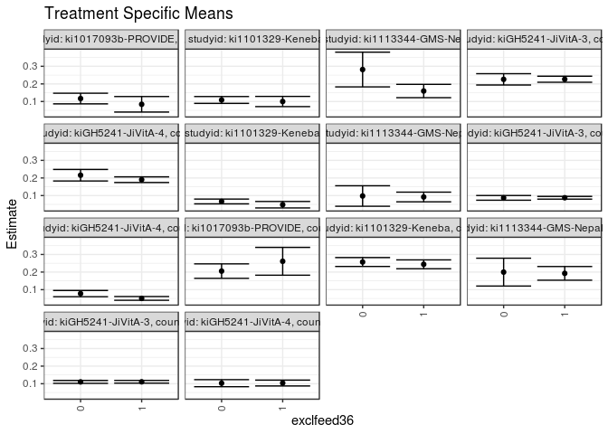

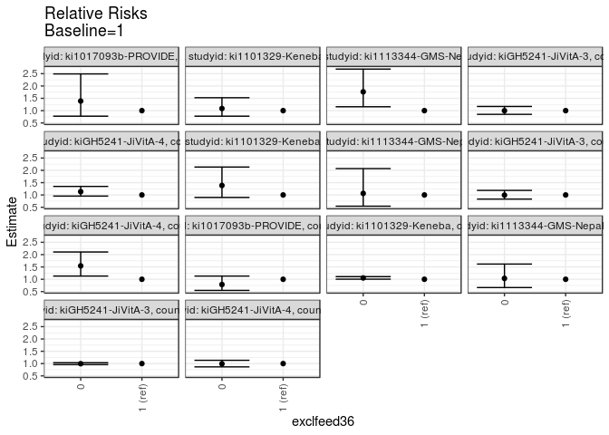

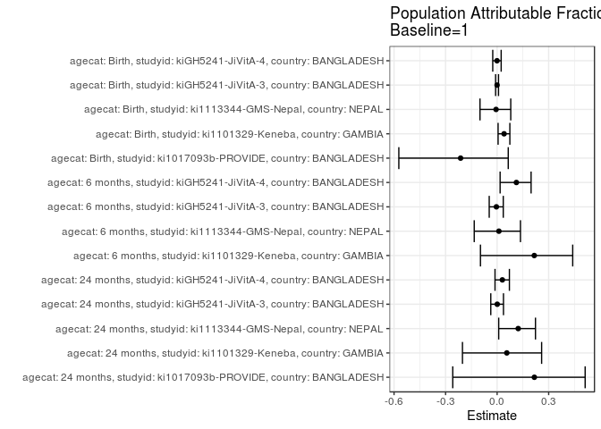

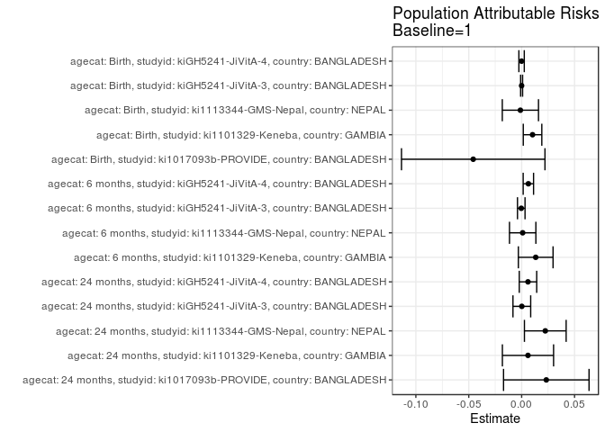

## Results Table

### Parameter: TSM

| agecat | studyid | country | intervention_level | baseline_level | estimate | ci_lower | ci_upper |
| --- | --- | --- | --- | --- | --- | --- | --- |
| Birth | ki1017093b-PROVIDE | BANGLADESH | 1 | NA | 0.2610990 | 0.1821062 | 0.3400917 |
| Birth | ki1017093b-PROVIDE | BANGLADESH | 0 | NA | 0.2053957 | 0.1642338 | 0.2465575 |
| Birth | ki1101329-Keneba | GAMBIA | 1 | NA | 0.2438996 | 0.2186598 | 0.2691393 |
| Birth | ki1101329-Keneba | GAMBIA | 0 | NA | 0.2569851 | 0.2317245 | 0.2822457 |
| Birth | ki1113344-GMS-Nepal | NEPAL | 1 | NA | 0.1926372 | 0.1537683 | 0.2315061 |
| Birth | ki1113344-GMS-Nepal | NEPAL | 0 | NA | 0.1996309 | 0.1204774 | 0.2787844 |
| Birth | kiGH5241-JiVitA-3 | BANGLADESH | 1 | NA | 0.1109548 | 0.1033010 | 0.1186086 |
| Birth | kiGH5241-JiVitA-3 | BANGLADESH | 0 | NA | 0.1103801 | 0.1022951 | 0.1184652 |
| Birth | kiGH5241-JiVitA-4 | BANGLADESH | 1 | NA | 0.1039223 | 0.0873248 | 0.1205198 |
| Birth | kiGH5241-JiVitA-4 | BANGLADESH | 0 | NA | 0.1029956 | 0.0829932 | 0.1229981 |
| 6 months | ki1101329-Keneba | GAMBIA | 1 | NA | 0.0481641 | 0.0298404 | 0.0664879 |
| 6 months | ki1101329-Keneba | GAMBIA | 0 | NA | 0.0666931 | 0.0530465 | 0.0803397 |
| 6 months | ki1113344-GMS-Nepal | NEPAL | 1 | NA | 0.0920134 | 0.0644547 | 0.1195722 |
| 6 months | ki1113344-GMS-Nepal | NEPAL | 0 | NA | 0.0977341 | 0.0395728 | 0.1558954 |
| 6 months | kiGH5241-JiVitA-3 | BANGLADESH | 1 | NA | 0.0876627 | 0.0799147 | 0.0954107 |
| 6 months | kiGH5241-JiVitA-3 | BANGLADESH | 0 | NA | 0.0870572 | 0.0736762 | 0.1004382 |
| 6 months | kiGH5241-JiVitA-4 | BANGLADESH | 1 | NA | 0.0502460 | 0.0396003 | 0.0608918 |
| 6 months | kiGH5241-JiVitA-4 | BANGLADESH | 0 | NA | 0.0775718 | 0.0597769 | 0.0953667 |
| 24 months | ki1017093b-PROVIDE | BANGLADESH | 1 | NA | 0.0841647 | 0.0401052 | 0.1282241 |
| 24 months | ki1017093b-PROVIDE | BANGLADESH | 0 | NA | 0.1169280 | 0.0867204 | 0.1471356 |
| 24 months | ki1101329-Keneba | GAMBIA | 1 | NA | 0.1001128 | 0.0711670 | 0.1290587 |
| 24 months | ki1101329-Keneba | GAMBIA | 0 | NA | 0.1087950 | 0.0893770 | 0.1282131 |
| 24 months | ki1113344-GMS-Nepal | NEPAL | 1 | NA | 0.1596832 | 0.1218886 | 0.1974777 |
| 24 months | ki1113344-GMS-Nepal | NEPAL | 0 | NA | 0.2816643 | 0.1830775 | 0.3802511 |
| 24 months | kiGH5241-JiVitA-3 | BANGLADESH | 1 | NA | 0.2266150 | 0.2093755 | 0.2438546 |
| 24 months | kiGH5241-JiVitA-3 | BANGLADESH | 0 | NA | 0.2259502 | 0.1938880 | 0.2580123 |
| 24 months | kiGH5241-JiVitA-4 | BANGLADESH | 1 | NA | 0.1903053 | 0.1742154 | 0.2063952 |
| 24 months | kiGH5241-JiVitA-4 | BANGLADESH | 0 | NA | 0.2157788 | 0.1829903 | 0.2485673 |

### Parameter: E(Y)

| agecat | studyid | country | intervention_level | baseline_level | estimate | ci_lower | ci_upper |
| --- | --- | --- | --- | --- | --- | --- | --- |
| Birth | ki1017093b-PROVIDE | BANGLADESH | NA | NA | 0.2153209 | 0.1786253 | 0.2520165 |
| Birth | ki1101329-Keneba | GAMBIA | NA | NA | 0.2541946 | 0.2294667 | 0.2789226 |
| Birth | ki1113344-GMS-Nepal | NEPAL | NA | NA | 0.1914460 | 0.1566101 | 0.2262820 |
| Birth | kiGH5241-JiVitA-3 | BANGLADESH | NA | NA | 0.1109177 | 0.1033745 | 0.1184610 |
| Birth | kiGH5241-JiVitA-4 | BANGLADESH | NA | NA | 0.1038534 | 0.0874500 | 0.1202568 |
| 6 months | ki1101329-Keneba | GAMBIA | NA | NA | 0.0614525 | 0.0503239 | 0.0725811 |
| 6 months | ki1113344-GMS-Nepal | NEPAL | NA | NA | 0.0929791 | 0.0681617 | 0.1177965 |
| 6 months | kiGH5241-JiVitA-3 | BANGLADESH | NA | NA | 0.0872876 | 0.0805483 | 0.0940269 |
| 6 months | kiGH5241-JiVitA-4 | BANGLADESH | NA | NA | 0.0565903 | 0.0475372 | 0.0656433 |
| 24 months | ki1017093b-PROVIDE | BANGLADESH | NA | NA | 0.1074523 | 0.0821617 | 0.1327430 |
| 24 months | ki1101329-Keneba | GAMBIA | NA | NA | 0.1060932 | 0.0899270 | 0.1222593 |
| 24 months | ki1113344-GMS-Nepal | NEPAL | NA | NA | 0.1820225 | 0.1461311 | 0.2179138 |
| 24 months | kiGH5241-JiVitA-3 | BANGLADESH | NA | NA | 0.2267779 | 0.2114523 | 0.2421034 |
| 24 months | kiGH5241-JiVitA-4 | BANGLADESH | NA | NA | 0.1962825 | 0.1816413 | 0.2109237 |

### Parameter: RR

| agecat | studyid | country | intervention_level | baseline_level | estimate | ci_lower | ci_upper |
| --- | --- | --- | --- | --- | --- | --- | --- |
| Birth | ki1017093b-PROVIDE | BANGLADESH | 1 | 1 | 1.0000000 | 1.0000000 | 1.000000 |
| Birth | ki1017093b-PROVIDE | BANGLADESH | 0 | 1 | 0.7866583 | 0.5476295 | 1.130018 |
| Birth | ki1101329-Keneba | GAMBIA | 1 | 1 | 1.0000000 | 1.0000000 | 1.000000 |
| Birth | ki1101329-Keneba | GAMBIA | 0 | 1 | 1.0536513 | 1.0038302 | 1.105945 |
| Birth | ki1113344-GMS-Nepal | NEPAL | 1 | 1 | 1.0000000 | 1.0000000 | 1.000000 |
| Birth | ki1113344-GMS-Nepal | NEPAL | 0 | 1 | 1.0363050 | 0.6638761 | 1.617663 |
| Birth | kiGH5241-JiVitA-3 | BANGLADESH | 1 | 1 | 1.0000000 | 1.0000000 | 1.000000 |
| Birth | kiGH5241-JiVitA-3 | BANGLADESH | 0 | 1 | 0.9948207 | 0.9567237 | 1.034435 |
| Birth | kiGH5241-JiVitA-4 | BANGLADESH | 1 | 1 | 1.0000000 | 1.0000000 | 1.000000 |
| Birth | kiGH5241-JiVitA-4 | BANGLADESH | 0 | 1 | 0.9910832 | 0.8666569 | 1.133373 |
| 6 months | ki1101329-Keneba | GAMBIA | 1 | 1 | 1.0000000 | 1.0000000 | 1.000000 |
| 6 months | ki1101329-Keneba | GAMBIA | 0 | 1 | 1.3847048 | 0.8989622 | 2.132912 |
| 6 months | ki1113344-GMS-Nepal | NEPAL | 1 | 1 | 1.0000000 | 1.0000000 | 1.000000 |
| 6 months | ki1113344-GMS-Nepal | NEPAL | 0 | 1 | 1.0621718 | 0.5451754 | 2.069442 |
| 6 months | kiGH5241-JiVitA-3 | BANGLADESH | 1 | 1 | 1.0000000 | 1.0000000 | 1.000000 |
| 6 months | kiGH5241-JiVitA-3 | BANGLADESH | 0 | 1 | 0.9930927 | 0.8321171 | 1.185210 |
| 6 months | kiGH5241-JiVitA-4 | BANGLADESH | 1 | 1 | 1.0000000 | 1.0000000 | 1.000000 |
| 6 months | kiGH5241-JiVitA-4 | BANGLADESH | 0 | 1 | 1.5438391 | 1.1310633 | 2.107255 |
| 24 months | ki1017093b-PROVIDE | BANGLADESH | 1 | 1 | 1.0000000 | 1.0000000 | 1.000000 |
| 24 months | ki1017093b-PROVIDE | BANGLADESH | 0 | 1 | 1.3892766 | 0.7748375 | 2.490960 |
| 24 months | ki1101329-Keneba | GAMBIA | 1 | 1 | 1.0000000 | 1.0000000 | 1.000000 |
| 24 months | ki1101329-Keneba | GAMBIA | 0 | 1 | 1.0867241 | 0.7749796 | 1.523872 |
| 24 months | ki1113344-GMS-Nepal | NEPAL | 1 | 1 | 1.0000000 | 1.0000000 | 1.000000 |
| 24 months | ki1113344-GMS-Nepal | NEPAL | 0 | 1 | 1.7638948 | 1.1578361 | 2.687189 |
| 24 months | kiGH5241-JiVitA-3 | BANGLADESH | 1 | 1 | 1.0000000 | 1.0000000 | 1.000000 |
| 24 months | kiGH5241-JiVitA-3 | BANGLADESH | 0 | 1 | 0.9970661 | 0.8501500 | 1.169371 |
| 24 months | kiGH5241-JiVitA-4 | BANGLADESH | 1 | 1 | 1.0000000 | 1.0000000 | 1.000000 |
| 24 months | kiGH5241-JiVitA-4 | BANGLADESH | 0 | 1 | 1.1338561 | 0.9545950 | 1.346780 |

### Parameter: PAR

| agecat | studyid | country | intervention_level | baseline_level | estimate | ci_lower | ci_upper |
| --- | --- | --- | --- | --- | --- | --- | --- |
| Birth | ki1017093b-PROVIDE | BANGLADESH | 1 | NA | -0.0457780 | -0.1135935 | 0.0220374 |
| Birth | ki1101329-Keneba | GAMBIA | 1 | NA | 0.0102951 | 0.0015359 | 0.0190543 |
| Birth | ki1113344-GMS-Nepal | NEPAL | 1 | NA | -0.0011912 | -0.0183035 | 0.0159211 |
| Birth | kiGH5241-JiVitA-3 | BANGLADESH | 1 | NA | -0.0000371 | -0.0009769 | 0.0009028 |
| Birth | kiGH5241-JiVitA-4 | BANGLADESH | 1 | NA | -0.0000689 | -0.0026162 | 0.0024784 |
| 6 months | ki1101329-Keneba | GAMBIA | 1 | NA | 0.0132884 | -0.0031046 | 0.0296814 |
| 6 months | ki1113344-GMS-Nepal | NEPAL | 1 | NA | 0.0009657 | -0.0115105 | 0.0134419 |
| 6 months | kiGH5241-JiVitA-3 | BANGLADESH | 1 | NA | -0.0003751 | -0.0039452 | 0.0031951 |
| 6 months | kiGH5241-JiVitA-4 | BANGLADESH | 1 | NA | 0.0063442 | 0.0014347 | 0.0112538 |
| 24 months | ki1017093b-PROVIDE | BANGLADESH | 1 | NA | 0.0232877 | -0.0171259 | 0.0637013 |
| 24 months | ki1101329-Keneba | GAMBIA | 1 | NA | 0.0059804 | -0.0182185 | 0.0301792 |
| 24 months | ki1113344-GMS-Nepal | NEPAL | 1 | NA | 0.0223393 | 0.0026266 | 0.0420520 |
| 24 months | kiGH5241-JiVitA-3 | BANGLADESH | 1 | NA | 0.0001628 | -0.0082177 | 0.0085434 |
| 24 months | kiGH5241-JiVitA-4 | BANGLADESH | 1 | NA | 0.0059772 | -0.0022662 | 0.0142207 |

### Parameter: PAF

| agecat | studyid | country | intervention_level | baseline_level | estimate | ci_lower | ci_upper |
| --- | --- | --- | --- | --- | --- | --- | --- |
| Birth | ki1017093b-PROVIDE | BANGLADESH | 1 | NA | -0.2126038 | -0.5721627 | 0.0647228 |
| Birth | ki1101329-Keneba | GAMBIA | 1 | NA | 0.0405008 | 0.0056655 | 0.0741156 |
| Birth | ki1113344-GMS-Nepal | NEPAL | 1 | NA | -0.0062221 | -0.0997003 | 0.0793100 |
| Birth | kiGH5241-JiVitA-3 | BANGLADESH | 1 | NA | -0.0003341 | -0.0088419 | 0.0081020 |
| Birth | kiGH5241-JiVitA-4 | BANGLADESH | 1 | NA | -0.0006635 | -0.0254948 | 0.0235665 |
| 6 months | ki1101329-Keneba | GAMBIA | 1 | NA | 0.2162384 | -0.0969883 | 0.4400284 |
| 6 months | ki1113344-GMS-Nepal | NEPAL | 1 | NA | 0.0103861 | -0.1332904 | 0.1358476 |
| 6 months | kiGH5241-JiVitA-3 | BANGLADESH | 1 | NA | -0.0042968 | -0.0460295 | 0.0357710 |
| 6 months | kiGH5241-JiVitA-4 | BANGLADESH | 1 | NA | 0.1121085 | 0.0173711 | 0.1977120 |
| 24 months | ki1017093b-PROVIDE | BANGLADESH | 1 | NA | 0.2167257 | -0.2582366 | 0.5123980 |
| 24 months | ki1101329-Keneba | GAMBIA | 1 | NA | 0.0563689 | -0.2017297 | 0.2590349 |
| 24 months | ki1113344-GMS-Nepal | NEPAL | 1 | NA | 0.1227283 | 0.0092193 | 0.2232331 |
| 24 months | kiGH5241-JiVitA-3 | BANGLADESH | 1 | NA | 0.0007180 | -0.0369272 | 0.0369964 |
| 24 months | kiGH5241-JiVitA-4 | BANGLADESH | 1 | NA | 0.0304522 | -0.0123021 | 0.0714009 |